# Visual Evidences for Matt Ridley’s Hypothesis on World Population

Nikitha Agarampalli

February 16, 2018

## Introduction:

A nation’s economy is essentially driven by good strategists - political, financial etc. It is, then, the economy that creates opportunities and demand better lifestyles. In fact, most developing/underdeveloped nations believe that they survive while the rest of the world lives. The quality of living portrayed by the media is the primary source of assessment. Hence, developing/underdeveloped nations are working to become strong economies, create in-house opportunities and thereby, intend to uplift their lives to a first-world quality. The economy is one way to reason out fertility rates. However, every theory has multiple dimensions. Few aspects which, we think, needs to be considered are the closing note to this report. No Sneak Peek !

But firstly,

## How does the world population vary with time ?

```r
#The data set has the population per country from 1960-2016
population_country_wise <- read_csv("World_Pop_CountryWise.csv")

population_country_wise <- select(population_country_wise, `1960`:`2016`)
population_country_wise <- population_country_wise[complete.cases(population_country_wise),]

#columnar sum to find out annual worldwide population
world_population <- apply(population_country_wise, 2, sum)
world_population <- data.frame(colnames(population_country_wise),world_population)
colnames(world_population) <- c("Year","Population")
```

```r
world_population_ts <- ts(world_population[2],start=c(1960,1))
world_population_ts_percent <-abs( x = world_population_ts/
          stats::lag(world_population_ts, -1) -1  )*100
world_population_ts_percent <- rbind(0,world_population_ts_percent)
world_population <- cbind(world_population_ts_percent,
                        world_population)
world_population <-filter(world_population,
                        world_population_ts_percent>0)
```

## PLOT - 1

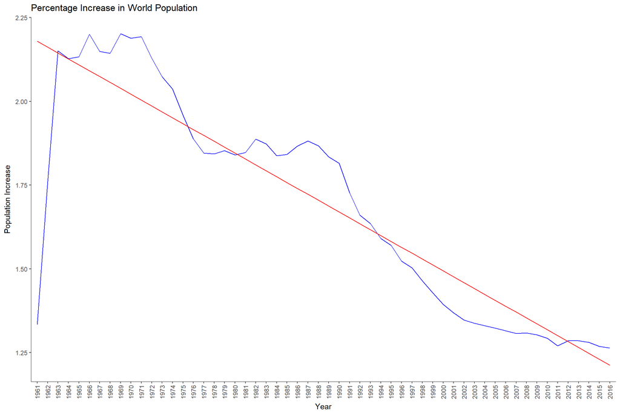

```r
#common graph properties that would be used across this document
graph_commons <- theme( panel.background = element_blank(),
    axis.line = element_line(colour = "black", size = 0.25),
    axis.text.x = element_text(angle = 90, hjust=1, vjust = .5))


ggplot(world_population, aes(x=Year, y=world_population_ts, group = 1)) + geom_line()+
     geom_line(size=0.5,colour = "blue") +
    stat_smooth(method=lm, se= FALSE, colour = "red", size = 0.5) +
    xlab("Year") + ylab("Population Increase") +
    ggtitle("Percentage Increase in World Population") + graph_commons
```

### Observations:

It is good to note that,  
1. The decrease is not steady.  
2. Everytime there is a surge, it is not as huge as the previous one.Example, There seems to be an increase in population between 1964- 1974 which is larger than the one between 1980-1992.  
3. However, this seems to work the other way around in the case of decreases. Every level of plunge seems to dip deeper, compared to the previous one. And, the population surge levels do not seem to compensate for the plunge.

*Mathematically, if we think of the data as waves, they seem to calm down over time, and is expected to eventually stabilize.*

According to Ridley’s theory, the fertility/replacement rate is 2.1, below which the population is expected to shrink. From the UN data, we have the annual fertility rates per country. We can, then, derive the average global fertility rate. By putting them all together, we could do a comparative study on where individual countries lie in terms of fertility rates with respect to the replacement rate and global average fertility. Since, Ridley’s theory talks about fertility rates in rich and developing countries, it would be helpful to put a few such countries in the pool to understand his perspective.

```r
#compute annual average global fertility rate
country_fRate <- read_csv("Fertility_Rate_CountryWise.csv")
country_fRate <- select(country_fRate, `Country Name`,`1960`:`2015`)
average_fRate <- colMeans(country_fRate[-1], na.rm = TRUE)
average_fRate <- data.frame(names(average_fRate),average_fRate)
colnames(average_fRate) <- c("Year","AverageFertilityRate")
str(average_fRate)
```

```
## 'data.frame':    56 obs. of  2 variables:
##  $ Year                : Factor w/ 56 levels "1960","1961",..: 1 2 3 4 5 6 7 8 9 10 ...
##  $ AverageFertilityRate: num  5.51 5.49 5.5 5.5 5.46 ...
```

```r
#subset of annual feritlity rates of developing countries
fRate_developing <- subset(country_fRate,
                                  country_fRate$`Country Name` == "Argentina" |                                   country_fRate$`Country Name` == "India" |
                                  country_fRate$`Country Name` == "Mexico" |
                                  country_fRate$`Country Name` == "Russia")
fRate_developing.melted <- melt(fRate_developing,
                                        id=("Country Name"))
colnames(fRate_developing.melted) <- c("Country", "Year", "FertilityRate")
#tag them as developing for an additional visualization element
fRate_developing.melted <- cbind(fRate_developing.melted,
                                CountryType="Developing")
```

```r
#subset of annual feritlity rates of newly developed countries
fRate_newly_developed <- subset(country_fRate,
                                country_fRate$`Country Name` == "Brazil" |
                                 country_fRate$`Country Name` == "China" |
                                 country_fRate$`Country Name` == "Chile" |
                                 country_fRate$`Country Name` == "Singapore")
fRate_newly_developed
```

```
## # A tibble: 4 x 57
##   `Country Name` `1960` `1961` `1962` `1963` `1964` `1965` `1966` `1967`
##   <chr>           <dbl>  <dbl>  <dbl>  <dbl>  <dbl>  <dbl>  <dbl>  <dbl>
## 1 Brazil           6.07   6.05   6.00   5.94   5.85   5.73   5.60   5.45
## 2 Chile            5.10   5.05   5.00   4.93   4.84   4.75   4.63   4.50
## 3 China            5.75   5.92   6.09   6.24   6.35   6.40   6.38   6.29
## 4 Singapore        5.76   5.41   5.21   5.16   4.97   4.66   4.46   3.91
## # ... with 48 more variables: `1968` <dbl>, `1969` <dbl>, `1970` <dbl>,
## #   `1971` <dbl>, `1972` <dbl>, `1973` <dbl>, `1974` <dbl>, `1975` <dbl>,
## #   `1976` <dbl>, `1977` <dbl>, `1978` <dbl>, `1979` <dbl>, `1980` <dbl>,
## #   `1981` <dbl>, `1982` <dbl>, `1983` <dbl>, `1984` <dbl>, `1985` <dbl>,
## #   `1986` <dbl>, `1987` <dbl>, `1988` <dbl>, `1989` <dbl>, `1990` <dbl>,
## #   `1991` <dbl>, `1992` <dbl>, `1993` <dbl>, `1994` <dbl>, `1995` <dbl>,
## #   `1996` <dbl>, `1997` <dbl>, `1998` <dbl>, `1999` <dbl>, `2000` <dbl>,
## #   `2001` <dbl>, `2002` <dbl>, `2003` <dbl>, `2004` <dbl>, `2005` <dbl>,
## #   `2006` <dbl>, `2007` <dbl>, `2008` <dbl>, `2009` <dbl>, `2010` <dbl>,
## #   `2011` <dbl>, `2012` <dbl>, `2013` <dbl>, `2014` <dbl>, `2015` <dbl>
```

```r
fRate_newly_developed.melted <- melt(fRate_newly_developed, id=("Country Name"))
fRate_developing.melted
```

```
##       Country Year FertilityRate CountryType
## 1   Argentina 1960         3.109  Developing
## 2       India 1960         5.906  Developing
## 3      Mexico 1960         6.768  Developing
## 4   Argentina 1961         3.100  Developing
## 5       India 1961         5.902  Developing
## 6      Mexico 1961         6.762  Developing
## 7   Argentina 1962         3.089  Developing
## 8       India 1962         5.894  Developing
## 9      Mexico 1962         6.758  Developing
## 10  Argentina 1963         3.078  Developing
## 11      India 1963         5.880  Developing
## 12     Mexico 1963         6.754  Developing
## 13  Argentina 1964         3.068  Developing
## 14      India 1964         5.859  Developing
```

[output cut: 154 more lines]

```r
colnames(fRate_newly_developed.melted) <- c("Country", "Year", "FertilityRate")
#tag them as newlydeveloped for an additional visualization element
fRate_newly_developed.melted <- cbind(fRate_newly_developed.melted,CountryType="NewlyDeveloped")
```

```r
#subset of annual feritlity rates of developed countries
fRate_developed <- subset(country_fRate,
                            country_fRate$`Country Name` == "United States" |
                             country_fRate$`Country Name` == "Japan" |
                             country_fRate$`Country Name` == "Germany" |
                             country_fRate$`Country Name` == "Canada")

fRate_developed.melted <- melt(fRate_developed, id=("Country Name"))

colnames(fRate_developed.melted) <- c("Country", "Year", "FertilityRate")
#tag them as Rich for an additional visualization element
fRate_developed.melted <- cbind(fRate_developed.melted,CountryType="Rich")
```

```r
#subset of annual feritlity rates of underdeveloped countries
fRate_poor <- subset(country_fRate,
                             country_fRate$`Country Name` == "Haiti" |
                             country_fRate$`Country Name` == "Chad" |
                             country_fRate$`Country Name` == "Yemen" |
                             country_fRate$`Country Name` == "Mali" |
                             country_fRate$`Country Name` == "Ethiopia")

fRate_poor.melted <- melt(fRate_poor, id=("Country Name"))

colnames(fRate_poor.melted) <- c("Country", "Year", "FertilityRate")
#tag them as underdeveloped for an additional visualization element
fRate_poor.melted <- cbind(fRate_poor.melted,CountryType="Underdeveloped/Poor")

SelectedCountries <- rbind(fRate_poor.melted,fRate_developed.melted,fRate_newly_developed.melted,fRate_developing.melted)
```

In the above code, we just picked up a list of rich, developing, newly developed, and poor countries from the GDP data we had, and joined it with the fertility rate data.

Here is what it looks like:

## PLOT - 2

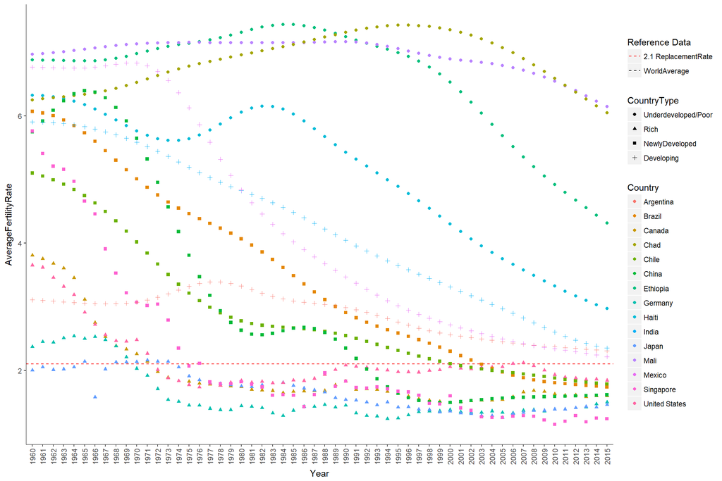

```r
#the base background plot needed for the two graphs below
base_plot <-  ggplot(data=average_fRate, aes(x=Year , y=AverageFertilityRate,
                        lty = "WorldAverage"))+geom_line()+
              geom_hline(aes(yintercept=2.1,lty = "2.1 ReplacementRate") ,
                         color="red") +
              scale_linetype_manual(name = "ReplacementRate", values = c(2, 2),
              guide=guide_legend(override.aes=list(color=c("red")))) +
              scale_linetype_manual(name = "Reference Data", values = c(2, 2),
              guide = guide_legend(override.aes =list(color=c("red","black"))))


#base plot + common properties of graphs in this document + required graph
 base_plot+graph_commons+
       geom_point(data=SelectedCountries,aes(x= Year, y =FertilityRate,
                 color=Country, shape = CountryType, group=Country))
```

### Observations:

But this got us to wonder, how do we account for gender imbalance scenarios ? What if the number of women had reduced, given that few nations had an issue of female infanticide. So, maybe a study of number of births per 1000 or N woman could have helped ?

Further more, a country-wise plot can be too much detail in a single graph. Hence, it would be helpful to take a step back and look at regions.

The below is a plot of same points but at a region level.

```r
#get annual gdp per region
nations_gdp_data <- read_csv("nations.csv")
nations_gdp_data <- select(nations_gdp_data,country,region)
colnames(nations_gdp_data) <- c("Country","Region")

regional_data <- left_join(SelectedCountries,nations_gdp_data)
#create a regional summary of their annual average fertility rate
regional_data <- regional_data %>% group_by(Year,Region,CountryType)   %>% summarise( AvgFertility = mean(FertilityRate))
```

## PLOT - 3

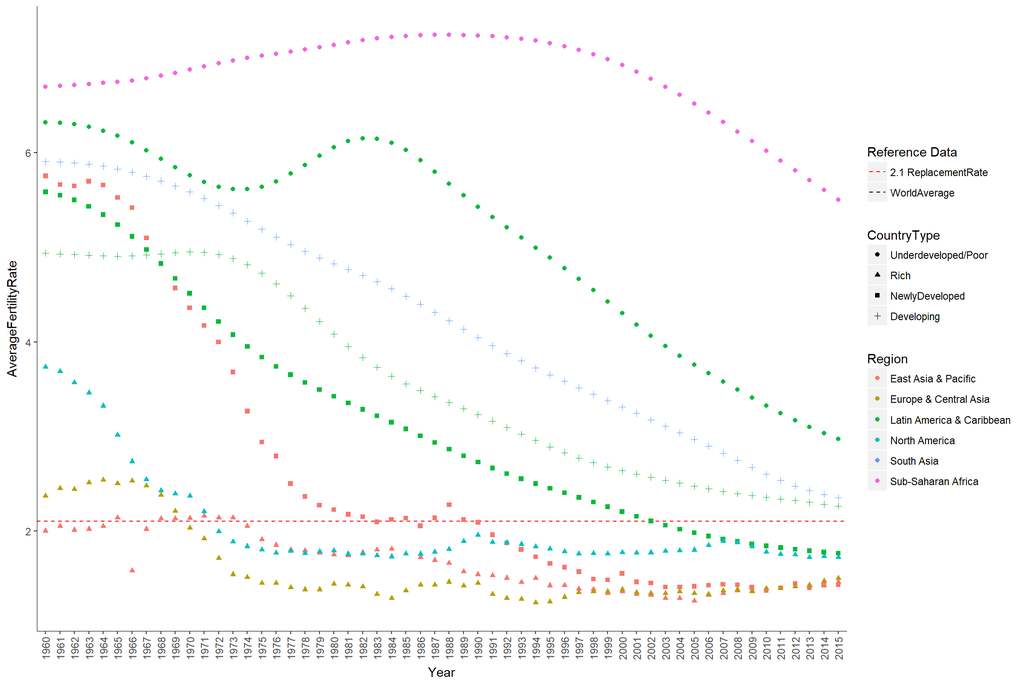

```r
     base_plot+ graph_commons +
         geom_point(data=regional_data,aes(x= Year, y =AvgFertility,
                    color = Region,shape = CountryType, group=Region))
```

## Does the fertility rate get impacted by the world GDP Per capita or education level attained by the woman ?

**Firstly, let us study Education level vs Fertility rate over the years.**

```r
#data preparation to load relationship between gdp per capita/education and fertility rate respectively.
femaleEducation <- read_csv("femaleEducation.csv")
gdpdata <- read.csv("nations.csv")

#compute avergae annual gdp
gdpdata<-  gdpdata %>% select(year,gdp_percap)
colnames(gdpdata) <- c('Year', 'GDP')
gdpdata$Year=as.numeric(as.character(gdpdata$Year))
gdpDataAvg <- gdpdata%>% group_by(Year) %>% summarize( AvgGDP= mean(GDP, na.rm=TRUE))
colnames(gdpDataAvg) <- c('Year', 'AvgGDP')
average_fRate$Year=as.numeric(as.character(average_fRate$Year))

#compute annual average number of secondary school female enrollments
enrollmentAvg <- femaleEducation %>% select(`Time Period`, `Observation Value`) %>% group_by(`Time Period`) %>% summarize( AvgEnrollment= mean(`Observation Value`))
colnames(enrollmentAvg) <- c('Year', 'AvgEnrollment')

#join based on year with the fertility rate data set
fertilityVsEducation <-inner_join(average_fRate, enrollmentAvg, by="Year")
fertilityVsPerCapita <- inner_join(average_fRate,gdpDataAvg, by="Year")
```

The yearly average number of woman enrolled for secondary education worldwide is taken as an indicator. Several studies state that orientation towards career and education have encouraged woman to plan better families/living. Infact, many developing and underdeveloped countries strongly strive to improve litracy in women to create general awareness, exposure and empowerment. Also, such countries have been promoting birth planners as an attempt to eliminate the taboo behind it. Personally, as educated women ourselves, we feel our education has given us a way to voice out facts.

## PLOT - 4.1

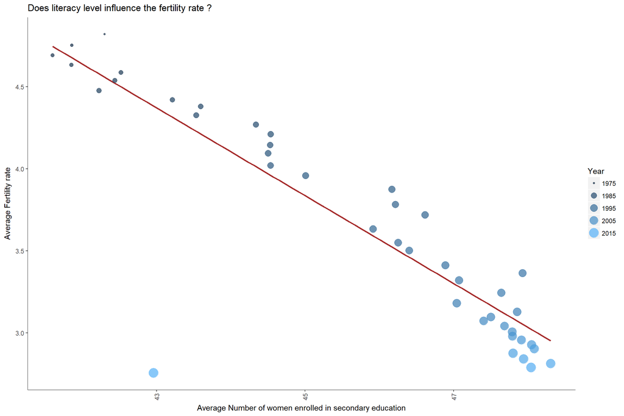

```r
#Number of women enrolled in secondary education vs Average Fertility Rate
ggplot(data= fertilityVsEducation, aes(x=AvgEnrollment, y=AverageFertilityRate, size=Year, color=Year) ) +
       stat_smooth(method=lm, se= FALSE, colour = "brown", size = 1)+
  #regression line to understand the data
       geom_point( alpha=0.7) + guides(colour = guide_legend()) +
       ggtitle("Does literacy level influence the fertility rate ?") + # adds a title
       xlab("Average Number of women enrolled in secondary education") +
       ylab("Average Fertility rate") +graph_commons #common graph properties used for all graphs
```

**Secondly, how fertility rate and GDP per capita are related?**

**GDP Per capita = GDP/ Population**

Therefore, GDP Per capita is inversely proportional to Population.

When the population decreases, it will uplift the GDP Per Capita. As the fertility rate decreases, there will obviously be a drop in population. According to the relationship above, the GDP Per Capita would increase.

## PLOT - 4.2

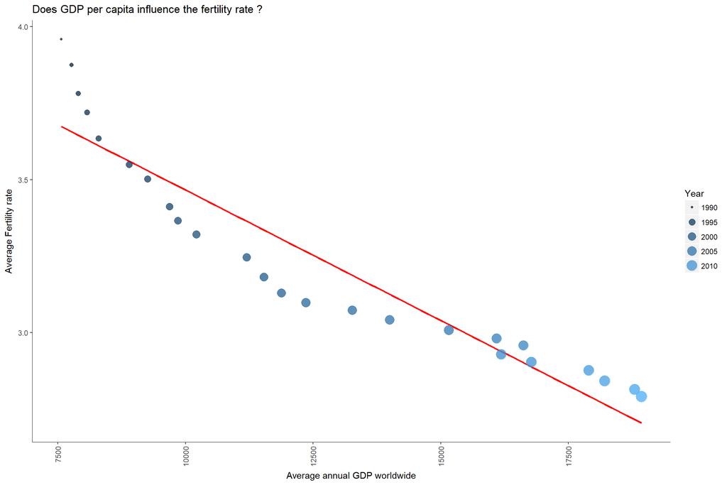

```r
#Annual world GDP Per capita vs Average Fertility Rate
ggplot(data= fertilityVsPerCapita, aes(x=AvgGDP, y=AverageFertilityRate, size=Year, color=Year) ) +
       stat_smooth(method=lm, se= FALSE, colour = "red", size = 1)+ #regression line to understand the data
       geom_point( alpha=0.8) + guides(colour = guide_legend()) +
       ggtitle("Does GDP per capita influence the fertility rate ?") +
       xlab("Average annual GDP worldwide") + ylab("Average Fertility rate")+ graph_commons #common graph properties used for all graphs
```

## Conclusion:

We felt that, Ridley’s theory explains the decrease population and fertility rates based on economic wellness - this certainly is an optimistic portrayal of the fact. In our opinion, Ridley, as a bioligists, could have considered the decay in average lifespan of a person and the reasons behind it. It would have been more logical to explain fertility rates or any theory by taking into account both the positives and negatives.

For example:  
1. How many kids died of cancer/diseases back in 1950 compared to 2015 ?  
2. How many life threatening diseases, terrorists attacks, natural disasters and other mishaps impact the lifespan/population ?  
3. Did the economical development increase the sense of competition and peer pressure/stress shortening our longevity - It is a known fact that a woman’s ability to give birth is affected by these factors.

*Hence, in our opinion, the analysis of fertility rate has many more explanatory pointers in addition to education and economy.*

## Additional Reading:

1. [Blog on The Rational Optimist by Matt Ridley](http://takingcareofmyownbusiness.com/2014/11/05/the-rational-optimist-by-matt-ridley/)
2. [Gates notes - Blog review on the book](https://www.gatesnotes.com/Books/Africa-Needs-Aid-Not-Flawed-Theories)